# Methods Draft SALAD

Lara Wieland & Claudia Ebrahimi

12/2/2021

## Methods

### Study Design

The study entailed a within-subjects design, in which participants performed the reversal learning task in two separate test sessions seven days apart.

### Task Design

Participants performed a probabilistic reversal learning task, which included 160 trials and comprised around 12 minutes. The task was programmed in Matlab (The MathWorks, Natick, MA) with Psychtoolbox. On every trial, participants had to decide between two cards, depicting a different geometric stimulus. The underlying reward structure was not explicitly instructed but could be inferred: reward probabilites associated with the two choice options were anticorrelated (i.e. whenever card A was rewarded, card B was a loss and vice versa). Furthermore, Participants were informed on the probabilistic nature of the task: the respective winning card was only rewarded in 80% of all trials. Right-side versus left-side location of the stimulus was randomized (Reiter et al. 2016).

#### Exemplary Reversal Learning Task

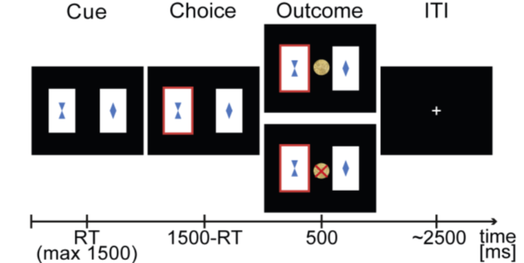

Adapted from Reiter (2016) (original [here](https://www.ncbi.nlm.nih.gov/pmc/articles/PMC6705653/))

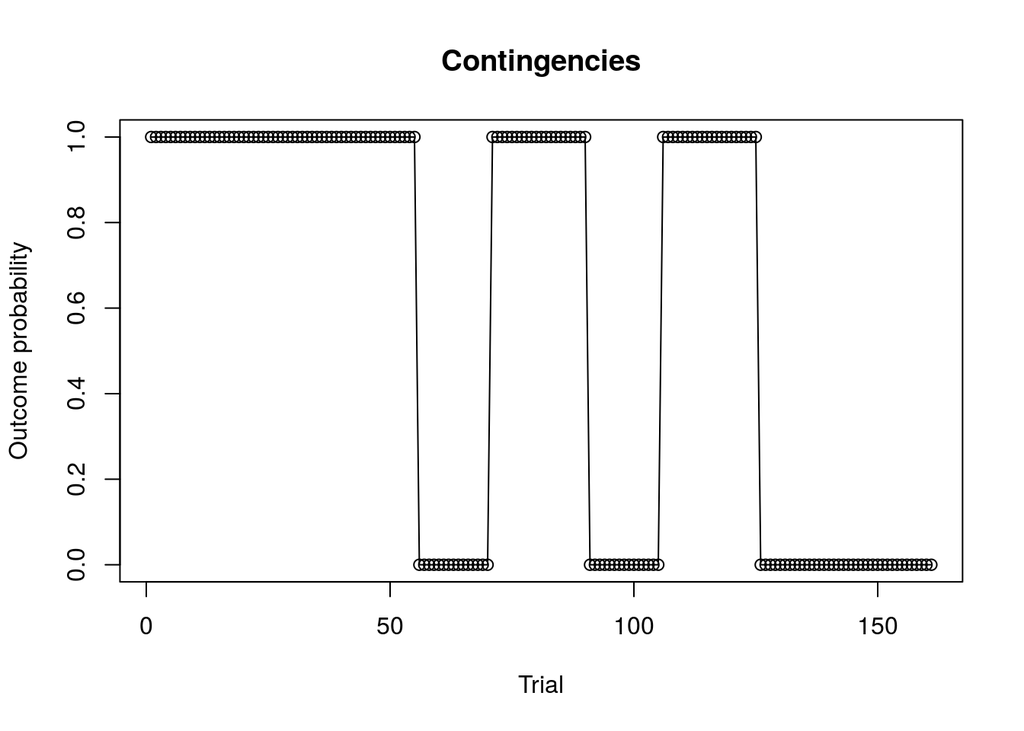

### Physiological stress response

Saliva was collected using Salivette saliva sampling tubes (SalivetteCortisol®, Sarstedt, Nuembrecht, Germany) to extract and measure salivary cortisol. Physiologically relevant cortisol increases were defined at a threshold of 1.5nmol per liter (nmol/l) increase post-stress (t3 through t6) above the lowest pre-stress level (t1 or t2) during the stress condition as described previously (Radenbach et al. 2015). Individual cortisol reactivity was determined by calculating the area under the curve with respect to ground (AUCg-stress and AUCg-control, according to Pruessner et al., 2003) separately for both conditions and subtracting AUCg-control from AUCg-stress.

### Behavioral Analyses

The statistical software R (version 3.6.3; R Foundation for Statistical Computing, Vienna, Austria) with the lme4 package (Bates et al. (2015)) for generalized linear mixed-effects models (Bates et al. 2015) was used. Task phase, condition day (CT/ST) and cortisol were modeled as fixed effects, subjects with a random intercept and outcome variables of correct performance, win-stay behavior, lose-switch-behavior and reaction times.

### Modeling

A comprehensive model space including single-update (1), double-update (2), and individual double update-learning (3), each with one or two learning rates (separate for wins and losses) in combination with a softmax and two inverse temperature parameters (separate for wins and losses) was applied. (Reiter et al. (2016))

## Results

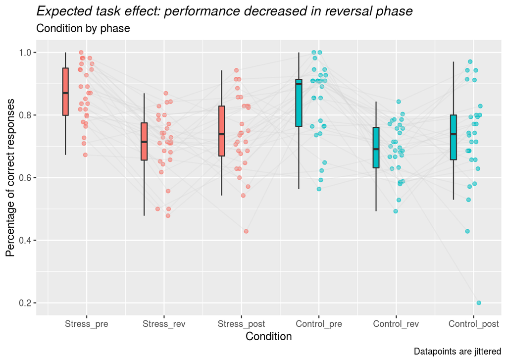

### References

Bates, Douglas, Martin Mächler, Benjamin M. Bolker, and Steven C. Walker. 2015. “Fitting Linear Mixed-Effects Models Using Lme4.” *Journal of Statistical Software* 67 (October). https://doi.org/10.18637/jss.v067.i01.

Radenbach, Christoph, Andrea M. F. Reiter, Veronika Engert, Zsuzsika Sjoerds, Arno Villringer, Hans Jochen Heinze, Lorenz Deserno, and Florian Schlagenhauf. 2015. “The Interaction of Acute and Chronic Stress Impairs Model-Based Behavioral Control.” *Psychoneuroendocrinology* 53 (March): 268–80. https://doi.org/10.1016/j.psyneuen.2014.12.017.

Reiter, Andrea M. F., Lorenz Deserno, Thomas Kallert, Hans Jochen Heinze, Andreas Heinz, and Florian Schlagenhauf. 2016. “Behavioral and Neural Signatures of Reduced Updating of Alternative Options in Alcohol-Dependent Patients During Flexible Decision-Making.” *Journal of Neuroscience* 36 (October): 10935–48. https://doi.org/10.1523/JNEUROSCI.4322-15.2016.